# Survival ML workflow mlr3 and mlr3proba

[John Zobolas](https://github.com/bblodfon)

Last updated: 07 February, 2023

# Overview

Using the `mlr3` ML framework and the `mlr3proba` R library, we will learn to:

- Create a survival task from a dataset and split it to train and test sets
- Define a Cox-Lasso model that makes both relative risk and survival distribution predictions and train/tune it on the train set
- Extract selected features from the trained Cox-Lasso model
- Make predictions using the trained Cox-Lasso model on the separate test set
- Measure the performance of our model (discrimination and calibration) using several survival measures
- Using resampling techniques, we will assess our model’s capacity for generalization (prediction on unseen data) and the stability of the model’s selected features

# TCGA BRCA Dataset

Load dataset and use only features age, ethnicity and the PAM50 genes (using George’s code):

```r
load('TCGA_clin_rna.RData')
RNA_count = TCGA_clin_rna$RNA_count
clin      = TCGA_clin_rna$clin

# extract the PAM50 genes of TCGA-BRCA patients
TCGA_PAM50 <- RNA_count[sapply(strsplit(rownames(RNA_count), '.', fixed = TRUE), function(x) x[[1]]) %in% c(
'ENSG00000077152', 'ENSG00000089685', 'ENSG00000143228', 'ENSG00000094804', 'ENSG00000134057',
'ENSG00000176890', 'ENSG00000101057', 'ENSG00000138180', 'ENSG00000165304', 'ENSG00000080986',
'ENSG00000171848', 'ENSG00000175063', 'ENSG00000117724', 'ENSG00000164611', 'ENSG00000174371',
'ENSG00000091651', 'ENSG00000011426', 'ENSG00000105173', 'ENSG00000117399', 'ENSG00000148773',
'ENSG00000142945', 'ENSG00000133627', 'ENSG00000136997', 'ENSG00000146648', 'ENSG00000186081',
'ENSG00000092621', 'ENSG00000062038', 'ENSG00000261857', 'ENSG00000128422', 'ENSG00000054598',
'ENSG00000104332', 'ENSG00000186847', 'ENSG00000091831', 'ENSG00000141424', 'ENSG00000107262',
'ENSG00000186868', 'ENSG00000082175', 'ENSG00000171604', 'ENSG00000115648', 'ENSG00000171791',
'ENSG00000135679', 'ENSG00000171428', 'ENSG00000129514', 'ENSG00000106605', 'ENSG00000099953',
'ENSG00000173890', 'ENSG00000160867', 'ENSG00000141738', 'ENSG00000151715', 'ENSG00000141736'), ]
# use gene symbols instead of Esembl IDs
rownames(TCGA_PAM50) <-
  c('UBE2T', 'BIRC5', 'NUF2', 'CDC6', 'CCNB1', 'TYMS', 'MYBL2', 'CEP55', 'MELK', 'NDC80', 'RRM2',
    'UBE2C', 'CENPF', 'PTTG1', 'EXO1', 'ORC6L', 'ANLN', 'CCNE1', 'CDC20', 'MKI67', 'KIF2C',
    'ACTR3B', 'MYC', 'EGFR', 'KRT5', 'PHGDH', 'CDH3', 'MIA', 'KRT17', 'FOXC1', 'SFRP1', 'KRT14',
    'ESR1', 'SLC39A6', 'BAG1', 'MAPT', 'PGR', 'CXXC5', 'MLPH', 'BCL2', 'MDM2', 'NAT1', 'FOXA1',
    'BLVRA', 'MMP11', 'GPR160', 'FGFR4', 'GRB7', 'TMEM45B', 'ERBB2')

# log2-transformation of the normalized count data
TCGA_PAM50 <- log2(TCGA_PAM50 + 1)

## for demonstration simplicity, PAM50 genes are used here
x <- cbind(age = clin$age, ethnicity = factor(clin$ethnicity), t(TCGA_PAM50))
y <- cbind(time = clin$time, status = clin$status)
```

Save reduced `data.frame` with only $52$ features for future use:

```r
data = cbind.data.frame(x,y)
saveRDS(data, file = 'data.rds')
```

# Survival ML workflow

For the rest of the analysis, we will borrow the terminology from the `mlr3` ecosystem of machine learning packages. See [mlr3 book](https://mlr3book.mlr-org.com/) for more details.

First, we load the necessary `mlr3` libraries (Lang et al. 2019; Sonabend et al. 2021) and some other useful ones:

```r
library(mlr3verse) # mlr3, mlr3pipeplines, mlr3learners, mlr3tuning, paradox, etc.
library(mlr3proba) # probabilistic learning and survival analysis
library(mlr3extralearners) # for lrn('surv.glmnet')
library(dplyr)
library(ggplot2)
```

## Survival task

We construct an `mlr3` *task* (our TCGA BRCA reduced dataset essentially):

```r
data = readRDS(file = 'data.rds')
task = mlr3proba::as_task_surv(x = data,
  time = 'time', event = 'status', id = 'BRCA-TCGA'
)
task
```

```
<TaskSurv:BRCA-TCGA> (1047 x 54)
* Target: time, status
* Properties: -
* Features (52):
  - dbl (52): ACTR3B, ANLN, BAG1, BCL2, BIRC5, BLVRA, CCNB1, CCNE1,
    CDC20, CDC6, CDH3, CENPF, CEP55, CXXC5, EGFR, ERBB2, ESR1, EXO1,
    FGFR4, FOXA1, FOXC1, GPR160, GRB7, KIF2C, KRT14, KRT17, KRT5, MAPT,
    MDM2, MELK, MIA, MKI67, MLPH, MMP11, MYBL2, MYC, NAT1, NDC80, NUF2,
    ORC6L, PGR, PHGDH, PTTG1, RRM2, SFRP1, SLC39A6, TMEM45B, TYMS,
    UBE2C, UBE2T, age, ethnicity
```

Since this is an [R6 class](https://r6.r-lib.org/index.html) object, we can use the dollar `$` to access various functions, fields (parameters), etc. For example, fitting the Kaplan-Meier (KM) using `survival::survfit()` is as simple as follows:

```r
task$kaplan()
```

```
Call: survfit(formula = f, data = data)

        n events median 0.95LCL 0.95UCL
[1,] 1047    149   10.8      10    20.4
```

`mlr3proba` comes with easy “standard” visualizations, e.g. to get the KM curve, you just do:

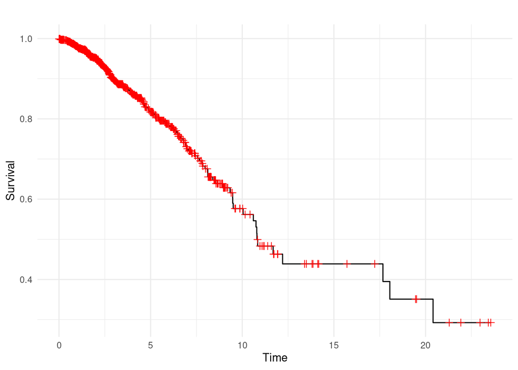

```r
# ?autoplot.TaskSurv
autoplot(task)
```

The red crosses show that our dataset is heavily censored.

Lastly, we partition our survival task into train and test sets $(80\%/20\%)$ to use for training and testing our model in the next sections:

```r
set.seed(42)
split = mlr3::partition(task, ratio = 0.8)
# split$train # => train set indexes
# split$test # => test set indexes
```

## Cox-Lasso

We define a Cox-Lasso model (a *learner* in `mlr3`) and print some basic information about it as follows:

```r
coxlasso = lrn('surv.cv_glmnet', alpha = 1, nfolds = 5, s = 'lambda.min')
coxlasso
```

```
<LearnerSurvCVGlmnet:surv.cv_glmnet>: Regularized Generalized Linear Model
* Model: -
* Parameters: alpha=1, nfolds=5, s=lambda.min
* Packages: mlr3, mlr3proba, mlr3extralearners, glmnet
* Predict Types:  [crank], lp
* Feature Types: logical, integer, numeric
* Properties: selected_features, weights
```

Note that this is essentially a wrapper around the `glmnet::cv.glmnet()` function, which performs an inner cross-validation for the `lambda` parameter (i.e. tries a lot of them) to decide which one is best (e.g. here the one the minimizes the Cox partial likelihood). So, given a dataset, `coxlasso` will be tuned and an appropriate `lambda` will be found. The `s` parameter denotes which `lambda` should be used for prediction. Use `coxlasso$help()` to see the respective documentation.

## Train

Train Cox-Lasso model (also tunes `lambda`):

```r
set.seed(42)
coxlasso$train(task, row_ids = split$train)
coxlasso$model # get the cv.glmet fit
```

```
Call:  (if (cv) glmnet::cv.glmnet else glmnet::glmnet)(x = data, y = target,      nfolds = 5L, alpha = 1, family = "cox")

Measure: Partial Likelihood Deviance

     Lambda Index Measure     SE Nonzero
min 0.01917    12   12.46 0.1880       8
1se 0.05334     1   12.52 0.1748       0
```

We can specify the $2$ clinical variables to be *mandatory* (i.e. not penalized) and re-train the model:

```r
#tail(task$feature_names) # age, ethnicity are the 2 last
pf = c(rep(1, length(task$feature_names) - 2), rep(0, 2))

coxlasso$reset() # un-train model
coxlasso$param_set$values$penalty.factor = pf # specify new parameter

set.seed(3)
coxlasso$train(task, row_ids = split$train) # retrain new model
coxlasso$model
```

```
Call:  (if (cv) glmnet::cv.glmnet else glmnet::glmnet)(x = data, y = target,      nfolds = 5L, alpha = 1, penalty.factor = c(1, 1, 1, 1, 1,      1, 1, 1, 1, 1, 1, 1, 1, 1, 1, 1, 1, 1, 1, 1, 1, 1, 1, 1,      1, 1, 1, 1, 1, 1, 1, 1, 1, 1, 1, 1, 1, 1, 1, 1, 1, 1, 1,      1, 1, 1, 1, 1, 1, 1, 0, 0), fam…

Measure: Partial Likelihood Deviance

     Lambda Index Measure     SE Nonzero
min 0.00994    15   12.30 0.2719      15
1se 0.03656     1   12.35 0.2562       2
```

## Selected features

The Cox-Lasso model performs feature selection. We can get the selected features from the model, based on the given lambda (here `s` = `lambda.min`):

```r
coxlasso$selected_features() # uses `s` (lambda.min)
```

```
 [1] "ANLN"      "BAG1"      "CEP55"     "EGFR"      "ERBB2"     "ESR1"
 [7] "FGFR4"     "GPR160"    "KIF2C"     "MDM2"      "MYC"       "ORC6L"
[13] "UBE2T"     "age"       "ethnicity"
```

or specify another `lambda`, e.g. `lambda.1se` (corresponding to a simpler Cox model, as most features have zero coefficients):

```r
coxlasso$selected_features(lambda = coxlasso$model$lambda.1se)
```

```
[1] "age"       "ethnicity"
```

## Predict relative risks

Let’s make predictions using our trained model on the test (validation) set:

```r
p = coxlasso$predict(task, row_ids = split$test)
head(as.data.table(p))
```

```
   row_ids      time status     crank        lp
1:       5 0.9527721  FALSE -3.329133 -3.329133
2:       6 4.0438056  FALSE -3.800766 -3.800766
3:      15 1.7385352  FALSE -2.786662 -2.786662
4:      45 4.5804244  FALSE -2.761110 -2.761110
5:      50 5.1279945  FALSE -3.736211 -3.736211
6:      54 6.6858316  FALSE -3.499691 -3.499691
```

So for every (new) patient in the test set, the Cox-Lasso model prediction is a linear predictor of the form $lp = \hat{\beta} X_{new}$. `crank` stands for continuous ranking/relative risk and it’s the same as `lp` for the Cox-Lasso model. See respective [documentation](https://mlr3proba.mlr-org.com/reference/PredictionSurv.html).

## Predict survival distributions

A Cox-PH (proportional hazards) model (and Cox-Lasso as a consequence) is a semi-parametric model, which means that it does not produce survival distribution predictions by default. This means that you can’t predict an individual survival curve per patient in the test set. However, using the function `survival::survfit.coxph()` you can transform the `cv.glmnet` risk predictions (`lp`) to survival distribution predictions. This transformation internally uses the Breslow estimator for the cumulative baseline hazard (see `stype` parameter).

Using `mlr3proba` (Sonabend et al. 2021), we can construct a pipeline (Binder et al. 2021) that combines the distribution predictions of a baseline model (e.g. Kaplan Meier) with the predictions of a model that predicts relative risk scores (e.g. Cox-Lasso). The whole idea is that the transformation (i.e. choice of the survival function form and baseline survival distribution estimator) becomes more *transparent* and part of the learner itself. Also, the same procedure (i.e. code) can be applied to other survival models under the corresponding assumptions of the transformation. See more details on the respective [documentation](https://mlr3proba.mlr-org.com/reference/mlr_pipeops_compose_distr.html).

We create a Cox-Lasso graph learner:

```r
coxlasso$reset() # un-train

# ?mlr_graphs_distrcompositor
coxlasso_grlrn = mlr3pipelines::ppl('distrcompositor',
  learner = coxlasso,
  estimator = 'kaplan', # KM estimator for the baseline
  form = 'ph', # Proportional Hazards form since we use a Cox-Lasso model
  graph_learner = TRUE
)
coxlasso_grlrn$id = 'Cox-Lasso'
coxlasso_grlrn$graph_model$plot(html = TRUE)
```

[interactive chart not shown]

We can now train the Cox-Lasso graph learner (fit/model object is exactly the same):

```r
set.seed(3)
coxlasso_grlrn$train(task, row_ids = split$train)
coxlasso_grlrn$model$surv.cv_glmnet$model
```

```
Call:  (if (cv) glmnet::cv.glmnet else glmnet::glmnet)(x = data, y = target,      nfolds = 5L, alpha = 1, penalty.factor = c(1, 1, 1, 1, 1,      1, 1, 1, 1, 1, 1, 1, 1, 1, 1, 1, 1, 1, 1, 1, 1, 1, 1, 1,      1, 1, 1, 1, 1, 1, 1, 1, 1, 1, 1, 1, 1, 1, 1, 1, 1, 1, 1,      1, 1, 1, 1, 1, 1, 1, 0, 0), fam…

Measure: Partial Likelihood Deviance

     Lambda Index Measure     SE Nonzero
min 0.00994    15   12.30 0.2719      15
1se 0.03656     1   12.35 0.2562       2
```

Get the survival distribution predictions ($distr$) along with the relative risk scores ($lp$):

```r
pred = coxlasso_grlrn$predict(task, row_ids = split$test)
head(as.data.table(pred))
```

```
   row_ids      time status     crank        lp     distr
1:       5 0.9527721  FALSE -3.329133 -3.329133 <list[1]>
2:       6 4.0438056  FALSE -3.800766 -3.800766 <list[1]>
3:      15 1.7385352  FALSE -2.786662 -2.786662 <list[1]>
4:      45 4.5804244  FALSE -2.761110 -2.761110 <list[1]>
5:      50 5.1279945  FALSE -3.736211 -3.736211 <list[1]>
6:      54 6.6858316  FALSE -3.499691 -3.499691 <list[1]>
```

We can request for the probability of survival at **any time point** of interest, e.g. at $1,5,10,20$ years and **for any patient in the test set**. This is all the information needed to produce an individual, i.e. per-patient survival curve. See more details in `?distr6::MatDist` and `?distr6::ExoticStatistics` objects of the distr6 `R` package used by `mlr3proba`.

So for the first two patients in our test set we have:

```r
times = c(1,5,10,20)
pred$distr$survival(times)[,c(1,2)]
```

```
        [,1]      [,2]
1  0.9993357 0.9995854
5  0.9925989 0.9953754
10 0.9804035 0.9877267
20 0.9633548 0.9769738
```

```r
# same logic for the cumulative hazard
# pred$distr$cumHazard(times)[,c(1,2)]
```

Lastly, we can visualize and compare the average survival predictions of all patients in the test set using the Cox-Lasso model with the Kaplan-Meier (KM) predictions (this is a form of *calibration* plot and it shows that our $distr$ predictions are not so good):

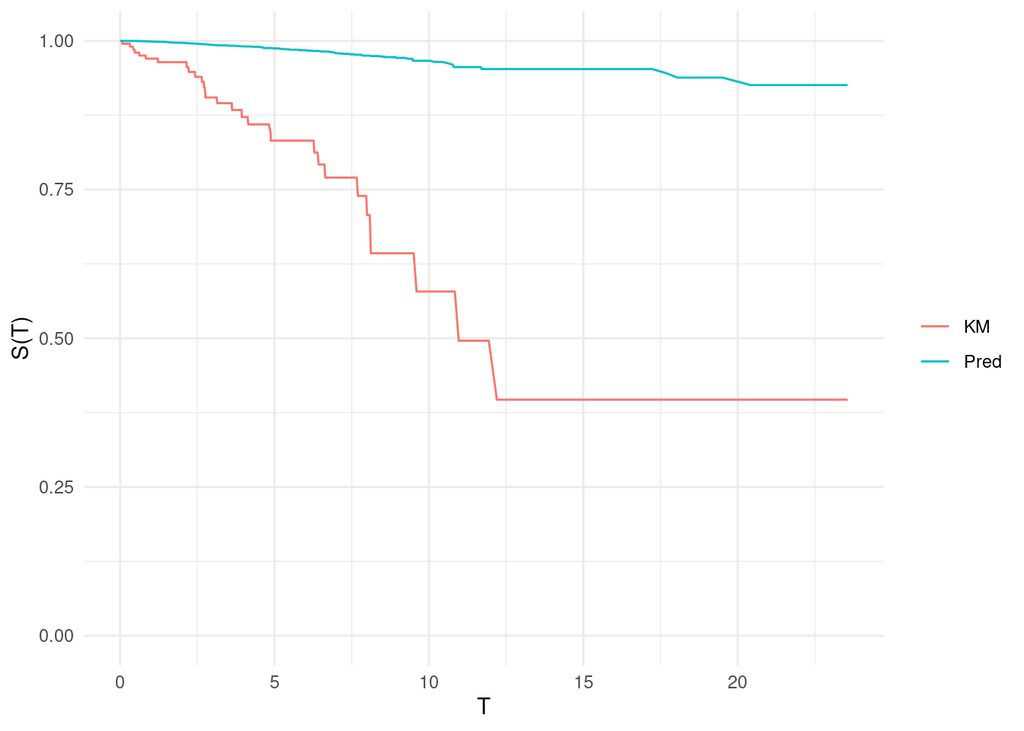

```r
# ?autoplot.PredictionSurv
autoplot(pred, type = 'calib', task = task, row_ids = split$test) +
  ylim(c(0,1))
```

## Model evaluation (discrimination)

We want to test our Cox-Lasso model and see how well it was able to **discriminate the patients in the test set**. For this we need to use the $lp$ relative risk predictions of Cox-Lasso model and measures such as the C-index and ROC-AUC. These measures can be *time-independent* (C-index, integrated $\text{ROC-AUC}$) or *time-dependent* (e.g. $\text{ROC-AUC}(t)$).

- Harrell’s C-index (Harrell et al. 1982):

```r
harrell_c = msr('surv.cindex')
harrell_c$id = 'surv.cindex.harrell'
```

Note that similar to the tasks, learners, prediction objects, etc. every `mlr3` measure is an `R6` object, so we can get some details about it:

```r
harrell_c
```

```
<MeasureSurvCindex:surv.cindex.harrell>
* Packages: mlr3, mlr3proba
* Range: [0, 1]
* Minimize: FALSE
* Average: macro
* Parameters: weight_meth=I, tiex=0.5, eps=0.001
* Properties: -
* Predict type: crank
* Return type: Score
```

So higher C-index is better (`minimize = FALSE`), it takes values in the $[0,1]$ range and uses the $crank$ predictions to calculate its score (which are the same as $lp$ for Cox-Lasso, as we saw earlier).

Get the Harrell’s C-index score:

```r
pred$score(harrell_c)
```

```
surv.cindex.harrell
          0.6188244
```

- Uno’s C-index (Uno et al. 2011):

```r
uno_c = msr('surv.cindex', weight_meth = 'G2')
uno_c$id = 'surv.cindex.uno'

# Uno's C needs the train data
pred$score(uno_c, task = task, train_set = split$train)
```

```
surv.cindex.uno
      0.6004459
```

- Uno’s ROC AUC (Uno et al. 2007) (integrated across all time points of the test set):

```r
uno_iauc = msr('surv.uno_auc') # integrated = TRUE # default
uno_iauc$id = 'surv.uno_iauc'
# sort(unique(pred$truth[,1])) # timepoints used

# needs the train dataset
# uno_iauc$properties
pred$score(uno_iauc, task = task, train_set = split$train)
```

```
surv.uno_iauc
    0.6645719
```

- Uno’s ROC AUC (at a specific time point, e.g. $10$ years):

```r
uno_auc = msr('surv.uno_auc')
uno_auc$id = 'surv.uno_auc.10'

# you have to set the parameters for this measure like this (fixed it, wait for Raphael to merge the PR)
uno_auc$param_set$values = list(integrated = FALSE, times = 10)

# needs the train dataset
pred$score(uno_auc, task = task, train_set = split$train)
```

```
surv.uno_auc.10
      0.6749081
```

## Model evaluation (calibration)

We want to test how well our Cox-Lasso model was **calibrated**. Usually we derive an estimation of the error between the survival distributions ($distr$ predictions) of the patients in the test set and their actual survival outcome (i.e. the survival task’s `time` and `status` variables). The most frequently used score is the Brier Score (Graf et al. 1999):

- Integrated Brier Score (across all time points of the test set):

```r
ibrier = msr('surv.brier', proper = TRUE)
# ibrier$help() # see documentation

# uses the `distr` predictions
ibrier$predict_type
```

```
[1] "distr"
```

```r
# better to use the train dataset for the Kaplan-Meier estimation of the censoring distribution, but can use the test set as well
pred$score(ibrier, task = task, train_set = split$train)
```

```
surv.graf
0.4044287
```

We can also get the *standard error* (the above result is the mean across all the test set’s patients) as follows:

```r
ibrier_se = msr('surv.brier', proper = TRUE, se = TRUE)
pred$score(ibrier_se, task = task, train_set = split$train)
```

```
 surv.graf
0.02253927
```

- Brier Score at a specific time point, e.g. $10$ years:

```r
brier10 = msr('surv.brier', proper = TRUE, integrated = FALSE, times = 10)
brier10$id = 'surv.graf.10'

# better to use the train dataset for the Kaplan-Meier estimation of the censoring distribution, but can use the test set as well
pred$score(brier10, task = task, train_set = split$train)
```

```
surv.graf.10
   0.4252442
```

- Get a **prediction error curve**, where the Brier score is evaluated on each separate time point of the test set:

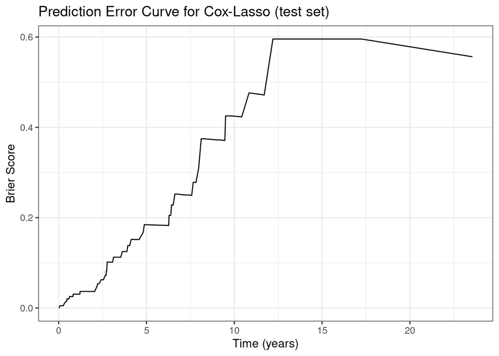

```r
mlr3proba::pecs(pred, measure = 'graf', train_task = task, train_set = split$train) +
  ggtitle('Prediction Error Curve for Cox-Lasso (test set)') +
  labs(y = 'Brier Score', x = 'Time (years)') +
  theme_bw(base_size = 12)
```

So it seems that our Cox-Lasso model’s survival predictions get worse with time, as we also observed when comparing these with the KM survival predictions of our test patient cohort.

Two more measures for assessing calibration:

- Right-censored Log Loss score (RCLL) (Avati et al. 2020):

```r
rcll = msr('surv.rcll')
pred$score(rcll)
```

```
surv.rcll
 4.680941
```

- D-calibration (Haider et al. 2020):

```r
dcal = msr('surv.dcalib')
pred$score(dcal)
```

```
surv.dcalib
   32.25961
```

View all available survival measures included in `mlr3proba` [here](https://mlr3proba.mlr-org.com/reference/#survival-measures)

# Resampling

Given that we don’t have a completely separate dataset to test our Cox-Lasso model’s performance, we proceed by resampling the BRCA-TCGA dataset to get an uncertainty quantification of our model’s *generalizability*, i.e. how well can it predict survival outcome in unseen data.

We will perform a **stratified split** of our BRCA-TCGA task to train and test sets (with a $80\%/20\%$ ratio as before). The number of splits will be set to $100$. Stratification on the censoring indicator `status` is important because we want our train and test sets to have the same censoring distribution as the initial dataset. Thus we can avoid measuring performance on test sets with severely different censoring distributions that might influence the performance scores.

Stratify survival task by `status`:

```r
coxlasso_grlrn$reset() # un-train model

task$col_roles$stratum = 'status'
task
```

```
<TaskSurv:BRCA-TCGA> (1047 x 54)
* Target: time, status
* Properties: strata
* Features (52):
  - dbl (52): ACTR3B, ANLN, BAG1, BCL2, BIRC5, BLVRA, CCNB1, CCNE1,
    CDC20, CDC6, CDH3, CENPF, CEP55, CXXC5, EGFR, ERBB2, ESR1, EXO1,
    FGFR4, FOXA1, FOXC1, GPR160, GRB7, KIF2C, KRT14, KRT17, KRT5, MAPT,
    MDM2, MELK, MIA, MKI67, MLPH, MMP11, MYBL2, MYC, NAT1, NDC80, NUF2,
    ORC6L, PGR, PHGDH, PTTG1, RRM2, SFRP1, SLC39A6, TMEM45B, TYMS,
    UBE2C, UBE2T, age, ethnicity
* Strata: status
```

Next, we define the resampling (`?mlr_resamplings_subsampling`), train the Cox-Lasso model on all train sets and store the fitted models for feature selection and evaluation:

```r
subsampling = rsmp('subsampling', repeats = 100, ratio = 0.8)

set.seed(42)
rr = mlr3::resample(task = task, learner = coxlasso_grlrn,
  resampling = subsampling, store_models = TRUE, store_backends = TRUE)
```

## Performance evaluation

We can use all the previously mentioned survival metrics to measure the performance of our trained Cox-Lasso models on the $100$ different test sets. Note that if a measure needs the train dataset it is automatically provided by the `ResampleResult` object (`rr`):

```r
measures = list(harrell_c, uno_c, uno_iauc, uno_auc, ibrier, brier10, rcll, dcal)

res = rr$score(measures = measures)
head(res)
```

```
             task   task_id            learner learner_id
1: <TaskSurv[55]> BRCA-TCGA <GraphLearner[38]>  Cox-Lasso
2: <TaskSurv[55]> BRCA-TCGA <GraphLearner[38]>  Cox-Lasso
3: <TaskSurv[55]> BRCA-TCGA <GraphLearner[38]>  Cox-Lasso
4: <TaskSurv[55]> BRCA-TCGA <GraphLearner[38]>  Cox-Lasso
5: <TaskSurv[55]> BRCA-TCGA <GraphLearner[38]>  Cox-Lasso
6: <TaskSurv[55]> BRCA-TCGA <GraphLearner[38]>  Cox-Lasso
                    resampling resampling_id iteration           prediction
1: <ResamplingSubsampling[20]>   subsampling         1 <PredictionSurv[20]>
2: <ResamplingSubsampling[20]>   subsampling         2 <PredictionSurv[20]>
3: <ResamplingSubsampling[20]>   subsampling         3 <PredictionSurv[20]>
4: <ResamplingSubsampling[20]>   subsampling         4 <PredictionSurv[20]>
5: <ResamplingSubsampling[20]>   subsampling         5 <PredictionSurv[20]>
6: <ResamplingSubsampling[20]>   subsampling         6 <PredictionSurv[20]>
   surv.cindex.harrell surv.cindex.uno surv.uno_iauc surv.uno_auc.10 surv.graf
1:           0.5679167       0.6090304     0.6628350       0.4719335 0.3255181
2:           0.5422131       0.4884603     0.4023684       0.5652588 0.3148992
3:           0.7604049       0.5740556     0.5941948       0.5235439 0.2855151
4:           0.6610169       0.5277736     0.5360690       0.5110032 0.2972719
5:           0.5800073       0.5655076     0.6160743       0.5388393 0.3518505
6:           0.5427837       0.6975740     0.6494779       0.6400328 0.2035609
   surv.graf.10 surv.rcll  surv.dcalib
1:    0.6161825  6.040633 1.026901e+07
2:    0.4473104  5.401748 1.050427e+04
3:    0.2969766  4.953528 2.544116e+01
4:    0.2365322  4.953830 2.275040e+01
5:    0.4387165  4.943446 3.370510e+01
6:    0.4228169  5.434970 4.223742e+02
```

We can easily extract and visualize the discrimination and calibration resampled performance of our Cox-Lasso model using several measures:

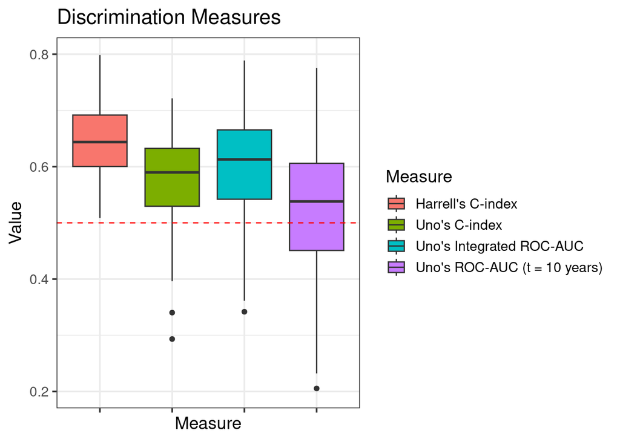

```r
set.seed(42)

# C-indexes, ROC-AUCs (integrated and at t = 10 years)
res[, .(surv.cindex.harrell, surv.cindex.uno, surv.uno_iauc, surv.uno_auc.10)] %>%
  tidyr::pivot_longer(cols = tidyselect::everything(),
    names_to = 'Measure', values_to = 'Value') %>%
  mutate(Measure = case_when(
    Measure == 'surv.cindex.harrell' ~ 'Harrell\'s C-index',
    Measure == 'surv.cindex.uno' ~ 'Uno\'s C-index',
    Measure == 'surv.uno_iauc' ~ 'Uno\'s Integrated ROC-AUC',
    Measure == 'surv.uno_auc.10' ~ 'Uno\'s ROC-AUC (t = 10 years)',
  )) %>%
  ggplot(aes(x = Measure, y = Value, fill = Measure)) +
    geom_boxplot() +
    ylim(c(0.2, 0.8)) +
    geom_hline(yintercept = 0.5, color = 'red', linetype = 'dashed') +
    theme_bw(base_size = 14) +
    labs(title = 'Discrimination Measures') +
    theme(axis.text.x = element_blank())
```

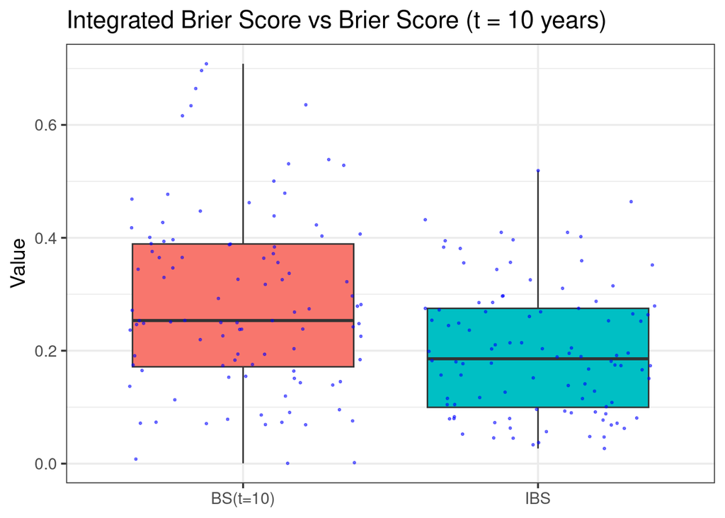

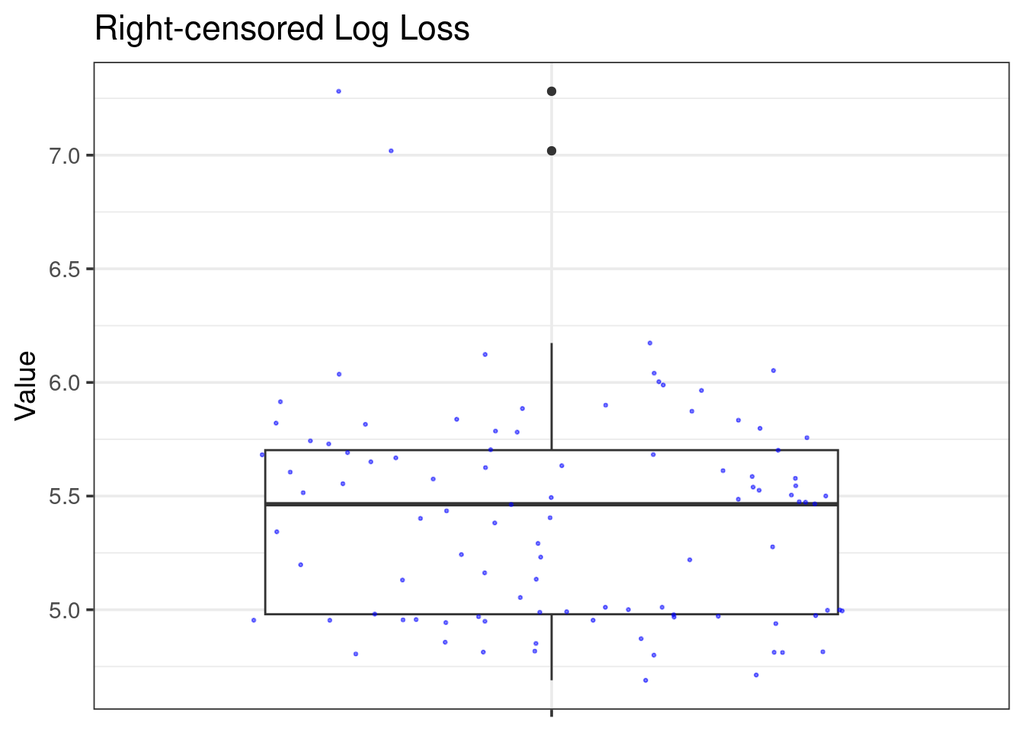

```r
# different scales for each measure, so we separate the plots
set.seed(42)

# Integrated Brier Score and Brier Score at t = 10 years
res[, .(surv.graf, surv.graf.10)] %>%
  tidyr::pivot_longer(cols = tidyselect::everything(),
    names_to = 'Measure', values_to = 'Value') %>%
  mutate(Measure = case_when(
    Measure == 'surv.graf' ~ 'IBS',
    Measure == 'surv.graf.10' ~ 'BS(t=10)'
  )) %>%
  ggplot(aes(x = Measure, y = Value, fill = Measure)) +
    geom_boxplot(show.legend = FALSE) +
    geom_jitter(color = 'blue', size = 0.5, alpha = 0.5, show.legend = FALSE) +
    labs(title = 'Integrated Brier Score vs Brier Score (t = 10 years)') +
    theme_bw(base_size = 14) +
    theme(axis.title.x = element_blank())

# RCLL
res[, .(surv.rcll)] %>%
  tidyr::pivot_longer(cols = tidyselect::everything(),
    names_to = 'Measure', values_to = 'Value') %>%
  mutate(Measure = case_when(
    Measure == 'surv.rcll' ~ 'RCLL'
  )) %>%
  ggplot(aes(x = Measure, y = Value)) +
    geom_boxplot(show.legend = FALSE) +
    geom_jitter(color = 'blue', size = 0.5, alpha = 0.5, show.legend = FALSE) +
    labs(title = 'Right-censored Log Loss') +
    theme_bw(base_size = 14) +
    theme(axis.title.x = element_blank(), axis.text.x = element_blank())
```

## Feature stability analysis

We can extract the selected features from all $100$ trained Cox-Lasso models and create a frequency selection table:

```r
# get selected features from all trained learners in a list
sf_list = lapply(rr$learners, function(learner) {
  learner$graph_model$pipeops$surv.cv_glmnet$learner_model$selected_features()
})

# make frequency selection table
n = length(sf_list)
fs_res = sort(table(unlist(sf_list)), decreasing = TRUE)
times = as.vector(unname(fs_res))
tibble::tibble(feat_name = names(fs_res), times = times, freq = times/n)
```

```
# A tibble: 35 × 3
   feat_name times  freq
   <chr>     <int> <dbl>
 1 age         100  1
 2 ethnicity   100  1
 3 UBE2T        53  0.53
 4 ORC6L        48  0.48
 5 ANLN         42  0.42
 6 ERBB2        40  0.4
 7 GPR160       35  0.35
 8 FGFR4        33  0.33
 9 CEP55        32  0.32
10 UBE2C        30  0.3
# … with 25 more rows
```

As `age` and `ethnicity` were not penalized, they have non-zero coefficients in all Cox-Lasso models and therefore are included in all selected features.

Lastly, we can use the `R` package `stabm` (Bommert and Lang 2021) to assess how similar the $100$ selected feature sets were. We will demonstrate the use of 3 metrics which measure the *stability* of the Cox-Lasso’s feature selection on the BRCA-TCGA dataset:

1. The Jaccard index
2. Nogueira’s metric (corrected for chance, i.e. independent of the number of features) (Nogueira, Sechidis, and Brown 2018)
3. Zucknick’s metric (extension of Jaccard index that considers the correlation between the features) (Zucknick, Richardson, and Stronach 2008):

```r
set.seed(42)
library(stabm)
jac = stabm::stabilityJaccard(features = sf_list, correction.for.chance = 'none')
nog = stabm::stabilityNogueira(features = sf_list, p = length(task$feature_names))

# Similarity of each pair of features using Pearson correlation
sim.mat = abs(stats::cor(x = task$data(cols = task$feature_names), method = 'p'))
zuck = stabm::stabilityZucknick(features = sf_list, sim.mat = sim.mat,
  threshold = 0.9, correction.for.chance = 'estimate', N = 100)

tibble::tibble(jaccard = jac, nogueira = nog, zucknick = zuck)
```

```
# A tibble: 1 × 3
  jaccard nogueira zucknick
    <dbl>    <dbl>    <dbl>
1   0.439    0.412    0.402
```

From the above values we conclude that the stability of Cox-Lasso’s feature selection is neither poor nor excellent but somewhere in between.

# References

Avati, Anand, Tony Duan, Sharon Zhou, Kenneth Jung, Nigam H Shah, and Andrew Y Ng. 2020. “Countdown Regression: Sharp and Calibrated Survival Predictions.” In *Proceedings of the 35th Uncertainty in Artificial Intelligence Conference*, edited by Ryan P Adams and Vibhav Gogate, 115:145–55. Proceedings of Machine Learning Research. PMLR. https://proceedings.mlr.press/v115/avati20a.html.

Binder, Martin, Florian Pfisterer, Michel Lang, Lennart Schneider, Lars Kotthoff, and Bernd Bischl. 2021. “mlr3pipelines - Flexible Machine Learning Pipelines in R.” *Journal of Machine Learning Research* 22 (184): 1–7. http://jmlr.org/papers/v22/21-0281.html.

Bommert, Andrea, and Michel Lang. 2021. “stabm: Stability Measures for Feature Selection.” *Journal of Open Source Software* 6 (59): 3010. https://doi.org/10.21105/joss.03010.

Graf, Erika, Claudia Schmoor, Willi Sauerbrei, and Martin Schumacher. 1999. “Assessment and comparison of prognostic classification schemes for survival data.” *Statistics in Medicine* 18: 2529–45. https://doi.org/10.1002/(SICI)1097-0258(19990915/30)18:17/18.

Haider, Humza, Bret Hoehn, Sarah Davis, and Russell Greiner. 2020. “Effective Ways to Build and Evaluate Individual Survival Distributions.” *Journal of Machine Learning Research* 21 (85): 1–63. http://jmlr.org/papers/v21/18-772.html.

Harrell, Frank E., Robert M. Califf, David B. Pryor, Kerry L. Lee, and Robert A. Rosati. 1982. “Evaluating the Yield of Medical Tests.” *JAMA: The Journal of the American Medical Association* 247 (18): 2543–46. https://doi.org/10.1001/jama.1982.03320430047030.

Lang, Michel, Martin Binder, Jakob Richter, Patrick Schratz, Florian Pfisterer, Stefan Coors, Quay Au, Giuseppe Casalicchio, Lars Kotthoff, and Bernd Bischl. 2019. “mlr3: A modern object-oriented machine learning framework in R.” *Journal of Open Source Software* 4 (44): 1903. https://doi.org/10.21105/JOSS.01903.

Nogueira, Sarah, Konstantinos Sechidis, and Gavin Brown. 2018. “On the Stability of Feature Selection Algorithms.” *Journal of Machine Learning Research* 18 (174): 1–54. http://jmlr.org/papers/v18/17-514.html.

Sonabend, Raphael, Franz J. Király, Andreas Bender, Bernd Bischl, and Michel Lang. 2021. “mlr3proba: an R package for machine learning in survival analysis.” *Bioinformatics* 37 (17): 2789–91. https://doi.org/10.1093/BIOINFORMATICS/BTAB039.

Uno, Hajime, Tianxi Cai, Michael J. Pencina, Ralph B. D’Agostino, and L. J. Wei. 2011. “On the C-statistics for evaluating overall adequacy of risk prediction procedures with censored survival data.” *Statistics in Medicine* 30 (10): 1105–17. https://doi.org/10.1002/SIM.4154.

Uno, Hajime, Tianxi Cai, Lu Tian, and L. J. Wei. 2007. “Evaluating Prediction Rules for t-Year Survivors With Censored Regression Models.” *Journal of the American Statistical Association* 102 (478): 527–37. https://doi.org/10.1198/016214507000000149.

Zucknick, Manuela, Sylvia Richardson, and Euan A Stronach. 2008. “Comparing the Characteristics of Gene Expression Profiles Derived by Univariate and Multivariate Classification Methods.” *Statistical Applications in Genetics and Molecular Biology* 7 (1). https://doi.org/doi:10.2202/1544-6115.1307.